# Coronary heart disease prediction

Leonardo Cerliani

20/7/2023

# Introduction

**Graded task Logistic regression**

Your task is to create a logistic regression model and to predict whether the patient has 10-year risk of future coronary heart disease (CHD). The data is given in the sheet Heart_desease. The dataset is from an ongoing cardiovascular study on residents of the town of Framingham, Massachusetts.

**Requirements:** 1. Create a logistic regression model and estimate predictions. 2. Interpret models’ coefficients and Odd ratios. 3. Assess the model with performance metrics."

**Evaluation criteria:** “1. How well the model creation in the task description is followed. 2. You can explain how you selected the best model. 3. You can interpret the models’ performance metrics and parameters. 4. You present fluent and clearly. Presentation should take 10-15 minutes. 5. Analytical approach to the problem”

**Sample questions:** “1. How have you selected your best model? 2. Why have you used the particular model’s performance metrics? 3. What is Odds ratio? 4. How do you interpret regression model’s intercept? 5. How do you interpret regression model’s coefficients?”

# Column description

- **Sex**: male or female(Nominal)
- **Age**: Age of the patient;(Continuous - Although the recorded ages have been truncated to whole numbers, the concept of age is continuous)
- **Current Smoker**: whether or not the patient is a current smoker (Nominal)
- **Cigs Per Day**: the number of cigarettes that the person smoked on average in one day.(can be considered continuous as one can have any number of cigarettes, even half a cigarette.)

Medical( history)

- **BP Meds**: whether or not the patient was on blood pressure medication (Nominal)
- **Prevalent Stroke**: whether or not the patient had previously had a stroke (Nominal)
- **Prevalent Hyp**: whether or not the patient was hypertensive (Nominal)
- **Diabetes**: whether or not the patient had diabetes (Nominal)
- **Tot Chol**: total cholesterol level (Continuous)
- **Sys BP**: systolic blood pressure (Continuous)
- **Dia BP**: diastolic blood pressure (Continuous)
- **BMI**: Body Mass Index (Continuous)
- **Heart Rate**: heart rate (Continuous - In medical research, variables such as heart rate though in fact discrete, yet are considered continuous because of large number of possible values.)
- **Glucose**: glucose level (Continuous)

Predict variable (desired target) - **10 year risk of coronary heart disease CHD** (binary: “1”, means “Yes”, “0” means “No”)

*Abbreviations:* - **EDA** : Exploratory Data Analysis - **EV** : Explanatory Variable (i.e. predictor)

# Load libraries and data

```r
library(tidyverse)
library(janitor)
library(emmeans)
library(dlookr)
library(flextable)
library(jtools)
library(GGally)
library(vcd)
library(ggstatsplot)
library(gridExtra)
library(caret)
library(jtools)
library(kableExtra)


select <- dplyr::select

bd <- "/Users/leonardo/My Drive/turing_college/Modules/Linear_and_Logistic_Regression/"

df <- read_csv(paste0(bd,"Graded_task_Heart_disease_data.csv")) %>%
 tibble %>%
 janitor::clean_names()

# change appropriate variables to factor
df <- df %>% mutate_at(
 c("male","education","current_smoker","bp_meds",
   "prevalent_stroke","prevalent_hyp",
   "diabetes","ten_year_chd"), factor
)

# df %>% glimpse()

# dlookr::diagnose(df) %>% flextable
```

# Split train/test

```r
set.seed(124)
N = nrow(df)
split_index <- sample(c("train","test"), N, replace = T, prob = c(0.6,0.4))

train <- df[which(split_index == "train"),]  # train set
test <- df[which(split_index == "test"),]  # test set
```

# Outliers check

We will carry out the check for outliers - and subsequently evaluate potential imputation for NA - only on the train data, and blindly apply this to the test. In a real world situation, the test set can grow continously, therefore we need to take decisions only on the train data.

The evaluation for potential NA imputation will be carried out later, just before modelling. The reason for this is that carrying out NA imputation first would bias the EDA.

**Observations** All the numerical values are in the norm, except for blood pressure. Specifically, the systolic blood pressure `sys_bp` is way too high, with about 4% of the participants having a bp > 180 (requiring immediate medical care).

In absence of more detailed information, we will remove all rows with `sys_bp` > 200

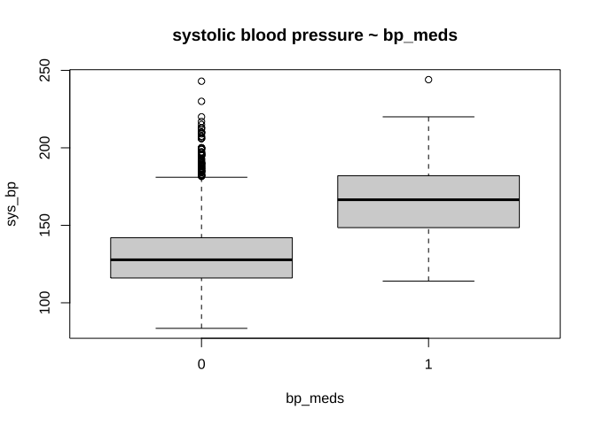

```r
# train %>% select_if(is.numeric) %>% summary()

# boxplot(glucose ~ diabetes, data = train, main = "glucose ~ diabetes")

boxplot(sys_bp ~ bp_meds, data = train, main = "systolic blood pressure ~ bp_meds")
```

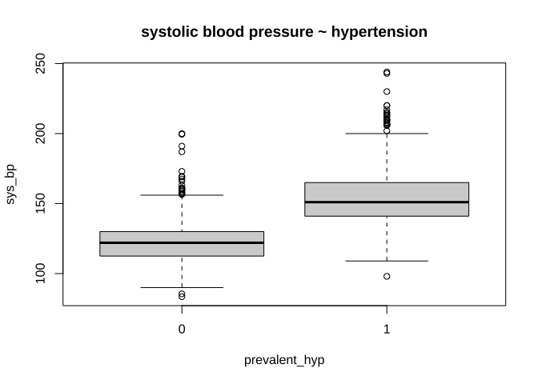

```r
boxplot(sys_bp ~ prevalent_hyp, data = train, main = "systolic blood pressure ~ hypertension")
```

```r
# percent of people with sys_bp > 180
pct_high_sys_bp <- round((train$sys_bp > 180) %>% sum() / nrow(train) * 100,2)

# xtabs(~ prevalent_hyp + bp_meds, data = train)

train <- train %>% filter(sys_bp <= 200)
test <- test %>% filter(sys_bp <= 200)
```

# EDA of numerical variables

Initially, we carry out t-tests to discover which EVs exhibit (corrected) significant differences between people with and without risk of CHD.

Then we will also examine the potential correlations between variables. If the latter are substantial, we will evaluate the possibility of discarding some EVs due to collinearity.

## Two-independent-samples t-tests

(an excercise in [fitting many models using `purrr::map`](https://www.youtube.com/watch?v=rz3_FDVt9eg))

```r
library(tidyr)

ttests <- train %>%
   # select("ten_year_chd", "age", "glucose") %>%

   select(-c("education","male","current_smoker","bp_meds",
           "prevalent_stroke","prevalent_hyp", "diabetes")) %>%
   na.omit() %>%

   # pivot longer to prepare the nesting
   pivot_longer(
      cols = -ten_year_chd,
      names_to = "variable", values_to = "value"
   ) %>%
   group_by(variable) %>%
   group_nest() %>%

   # fit a model to each nested df
   mutate(
    ttmod = map(data, ~ lm(value ~ ten_year_chd, data = .x))
   ) %>%

   # get the stats
   mutate(
      tidy = map(ttmod, broom::tidy)
   ) %>%
   unnest(tidy) %>%
   filter(term == "ten_year_chd1") %>%

   # correct for multiple comparisons
   mutate(adj_pval = p.adjust(p.value, method = "fdr")) %>%
   # filter(adj_pval <= 0.01) %>%
   relocate(adj_pval, .after=variable) %>%
   arrange(adj_pval)


ttests %>%
  select(variable, statistic, adj_pval) %>%
  rename(`t value` = statistic) %>%
  flextable() %>%
  set_formatter(adj_pval = function(x) sprintf("%.2e", x))
```

| variable | t value | adj_pval |
| --- | --- | --- |
| age | 11.7832923 | 3.00e-30 |
| sys_bp | 11.0925449 | 2.79e-27 |
| dia_bp | 7.3694242 | 6.36e-13 |
| glucose | 5.8491661 | 1.13e-08 |
| bmi | 5.6182364 | 3.46e-08 |
| tot_chol | 3.6874532 | 3.09e-04 |
| cigs_per_day | 2.0727204 | 4.38e-02 |
| heart_rate | 0.6443369 | 5.19e-01 |

### Age

```r
ggbetweenstats(
   data = train,
   x = ten_year_chd,
   y = age
)
```

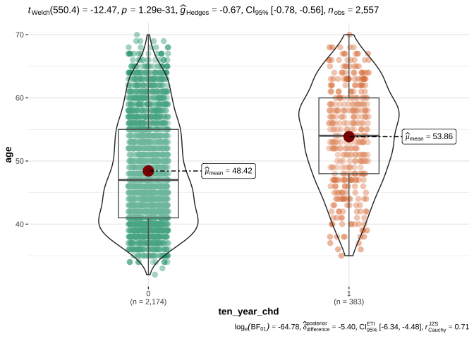

### Systolic blood pressure

```r
ggbetweenstats(
   data = train,
   x = ten_year_chd,
   y = sys_bp
)
```

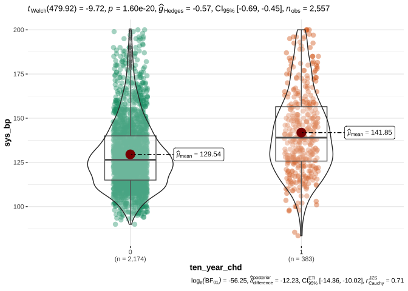

### Diastolic blood pressure

```r
#
ggbetweenstats(
   data = train,
   x = ten_year_chd,
   y = dia_bp
)
```

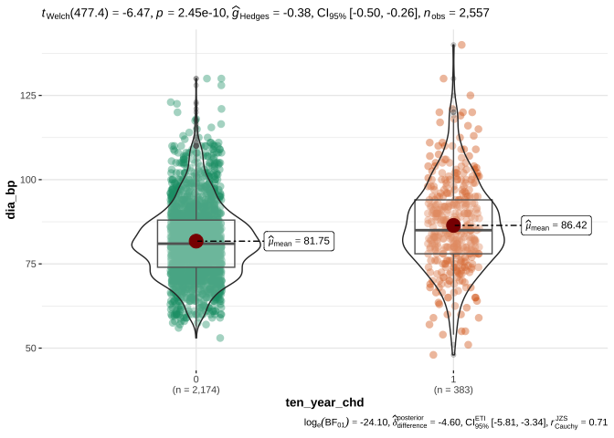

```r
#
ggbetweenstats(
   data = train,
   x = ten_year_chd,
   y = dia_bp
)
```

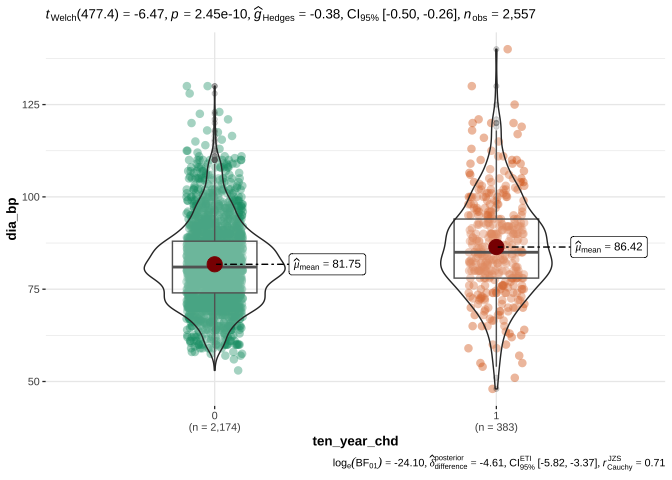

### BMI

```r
#
ggbetweenstats(
   data = train,
   x = ten_year_chd,
   y = bmi
)
```

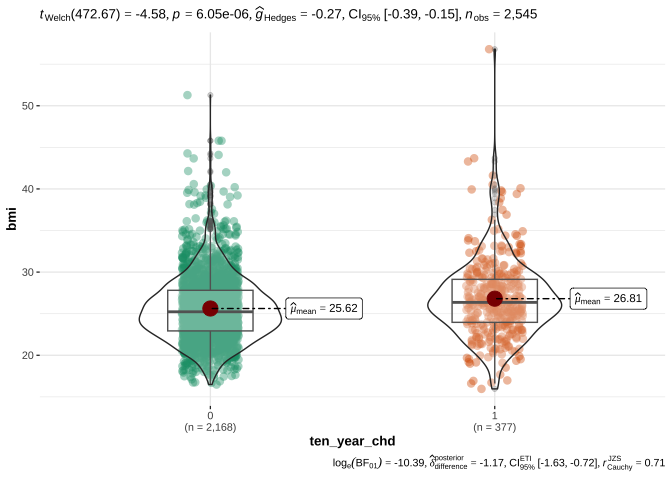

### Cholesterol level

```r
#
ggbetweenstats(
   data = train,
   x = ten_year_chd,
   y = tot_chol
)
```

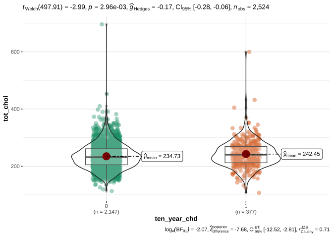

## Correlation matrix

Exploring the correlation matrix of the numerical variables to detect potential collinearity

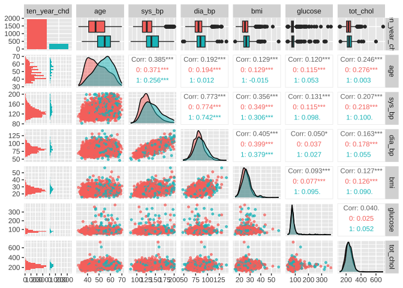

```r
train %>%
 # select(-c("education","male","current_smoker","bp_meds",
 #           "prevalent_stroke","prevalent_hyp", "diabetes")) %>%
 select(ten_year_chd, age, sys_bp, dia_bp, bmi, glucose, tot_chol) %>%
 na.omit() %>%
 # mutate_at(vars(-ten_year_chd), ~ log(. + 1)) %>%
 GGally::ggpairs(
    aes(color = ten_year_chd),
    upper = list(continuous = wrap("cor", size = 3)),
    lower = list(continuous = wrap("points", alpha = 0.7, size = 1)),
    diag = list(continuous = wrap("densityDiag", alpha = 0.5))
 )
```

## Observations - numerical EVs

- `age` appears to be the most discriminant variable for ten year CHD prediction. Other EVs which are significantly different (after correction with FDR) in people with and without CHD risk are `bmi`, `sys_bp`, `dia_bp`, `glucose`, `tot_chol`.
- the systolic `sys_bp` and diastolic `dia_bp` blood pressure are correlated with each other - as expected. Since CHD is especially related to hypertension, we will only use systolic blood pressure
- `bmi` and `age` are also correlated with blood pressure, however they appear to be important variables for CHD and their correlation with blood pressure is mild, so we will keep them
- the number of cigarettes per day (`cigs_per_day`) appears to have a small relationship with the group. A chi-square test pooling all the smokers and non-smokers (below) however fails to show a significant effect of smoking.

```r
# Chi square test to assess whether there is a significant different in the risk
# of CHD for smokers and non-smokers

train %>%
   mutate(smoker = ifelse(cigs_per_day == 0, 0, 1)) %>%
   select(ten_year_chd, smoker) %>%
   xtabs(~ ten_year_chd + smoker, data = .) %>%
   chisq.test() %>% tidy() %>% kable(format = "html") %>%
  add_header_above(c("Chi-Square CHD Risk ~ Smokers" = 4)) %>%
  kable_styling()
```

| Chi-Square CHD Risk ~ Smokers statistic | Chi-Square CHD Risk ~ Smokers p.value | Chi-Square CHD Risk ~ Smokers parameter | Chi-Square CHD Risk ~ Smokers method |
| --- | --- | --- | --- |
| 1.478407 | 0.224024 | 1 | Pearson’s Chi-squared test with Yates’ continuity correction |

# EDA of categorical variables

```r
# train %>% select_if(is.factor) %>% summary
```

As before for the numerical variables, we will first assess a dependence between risk of CHD and other categorical variables, and then explore the reciprocal relationships of all categorical variables to assess the presence of collinearity.

## Chi-square tests

### Sex (male)

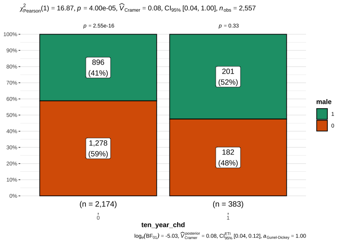

```r
library(ggstatsplot)

ggbarstats(
   data = train %>% select(ten_year_chd, male),
   x = male,
   y = ten_year_chd,
   label = "both"
)
```

### Hypertension

```r
ggbarstats(
   data = train %>% select(ten_year_chd, prevalent_hyp),
   x = prevalent_hyp,
   y = ten_year_chd,
   label = "both"
)
```

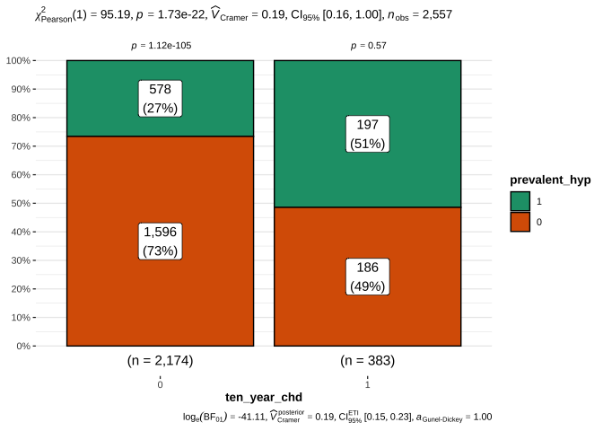

### Current smoker

```r
ggbarstats(
   data = train %>% select(ten_year_chd, current_smoker),
   x = current_smoker,
   y = ten_year_chd,
   label = "both"
)
```

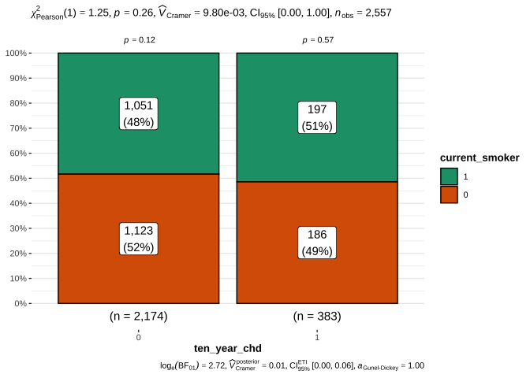

The absence of a relationship with smoking is quite surprising. One further visualization of the relationship between CHD risk and # of cigarettes per day shows that indeed there appear to be only a mild and not clear relationship.

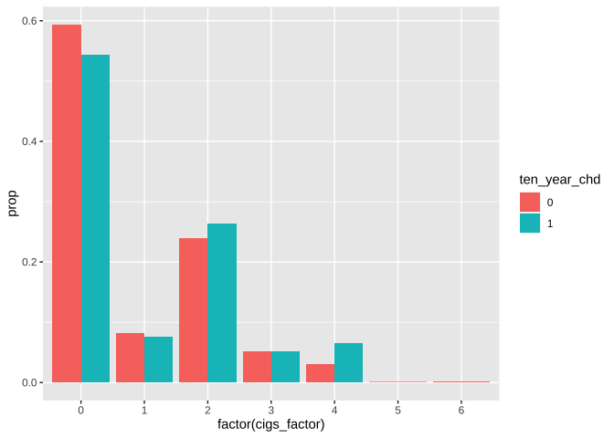

```r
# Suppress summarise info
options(dplyr.summarise.inform = FALSE)

train %>%
   select(ten_year_chd, cigs_per_day) %>%
   na.omit() %>%
   mutate(cigs_factor = round(cigs_per_day/10,0)) %>%
   group_by(ten_year_chd, cigs_factor) %>%
   summarise(count = n(), .group = "drop") %>%
   group_by(ten_year_chd) %>%
   mutate(prop = count / sum(count)) %>%
   select(ten_year_chd, cigs_factor, prop) %>%
   ggplot(aes(x = factor(cigs_factor), y = prop, fill = ten_year_chd)) +
   geom_bar(stat = "identity", position = "dodge")
```

### Blood pressure medication

```r
ggbarstats(
   data = train %>% select(ten_year_chd, bp_meds),
   x = bp_meds,
   y = ten_year_chd,
   label = "both"
)
```

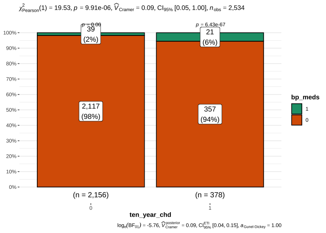

### Education

```r
ggbarstats(
   data = train %>% select(ten_year_chd, education),
   x = education,
   y = ten_year_chd,
   label = "both"
)
```

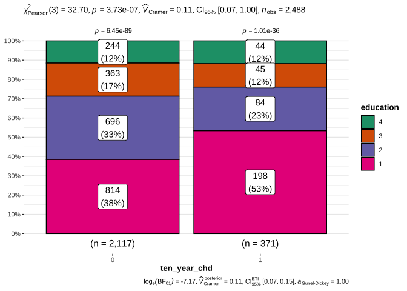

## Association matrix (categorical)

Graphically display the association between binary categorical variables, including `ten_year_chd` to assess the presence of correlated predictors

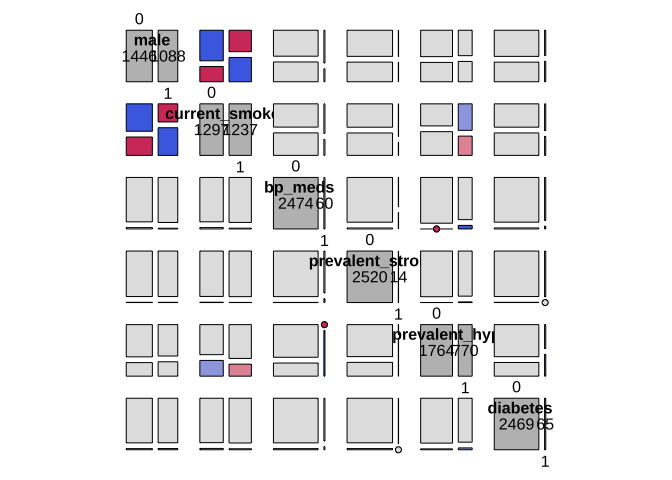

```r
library(vcd)

train_cat <- train %>% select_if(is.factor) %>% select(-c("ten_year_chd","education"))

pairs(
   table(train_cat),
   diag_panel = pairs_diagonal_mosaic(offset_varnames=-2.5),    #move down variable names
   upper_panel_args = list(shade = TRUE),                       #set shade colors
   lower_panel_args = list(shade = TRUE)
)
```

## Observations - categorical EVs

- The 10-year CHD risk appear to be associated with gender (male) and prevalence of hypertension
- There is also a relation between hypertension and smoking. However smoking per se appears not be significantly associated with CHD risk (!) - confirming the results above when we pooled together all smokers and non-smokers. Therefore we will not include numerical and categorical variables associated with smoking.
- Not surprisingly, people under blood pressure medication are also at high risk. We will also examine this, although only ~ 3% of the sample takes these medications

# Choice of predictors

**Numerical variables** Age (`age`), High blood pressure (`sys_bp`), body-mass index (`bmi`), glucose blood level (`glucose`), cholesterol blood level (`tot_chol`) appear to be involved in predicting the risk of CHD

**Categorical variables** Sex (`male`), hypertension (`prevalent_hyp`), blood pressure medications (`bp_meds`) and education (`education`) appear to be involved in predicting the risk of CHD.

There are widespread associations between numerical and categorical variables. This is *not* surprising for two reasons:

- some variables are proxy each other (e.g. `sys_bp`, `prevalence_hyp`, `bp_meds`)
- some variables are linked by known relationships: e.g. with `age`, the `bmi` increases, and both are likely to lead to increased blood pressure `sys_bp`, which in turn can lead to hypertension and relative medicaments

Despite this, we will enter all the selected variables in the model and assess the presence of collinearity using VIF.

## age

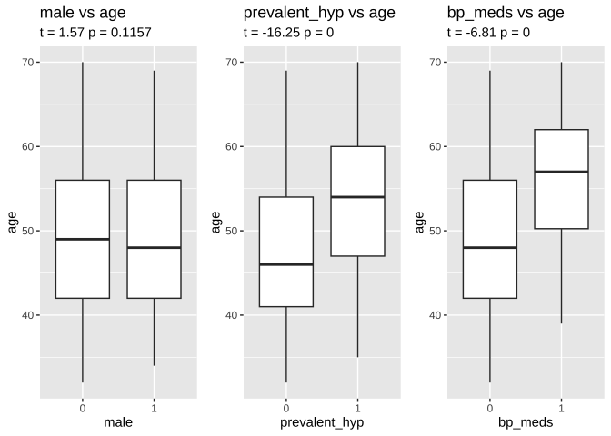

```r
library(gridExtra)

boxplot_tt <- function(response, predictor) {
   tt <- t.test(train[[response]] ~ train[[predictor]], data =train)

   res <- paste0("t = ", round(tt$statistic,2), " p = ", round(tt$p.value,4))

   p <- train %>% na.omit() %>%
      ggplot(aes(x = .data[[predictor]], y = .data[[response]])) +
      geom_boxplot() +
      labs(title = paste0(predictor," vs ", response),
           subtitle = res)

   return(p)

}

p1 <- boxplot_tt("age", "male")
p2 <- boxplot_tt("age", "prevalent_hyp")
p3 <- boxplot_tt("age", "bp_meds")

grid.arrange(p1, p2, p3, nrow = 1)
```

## bmi

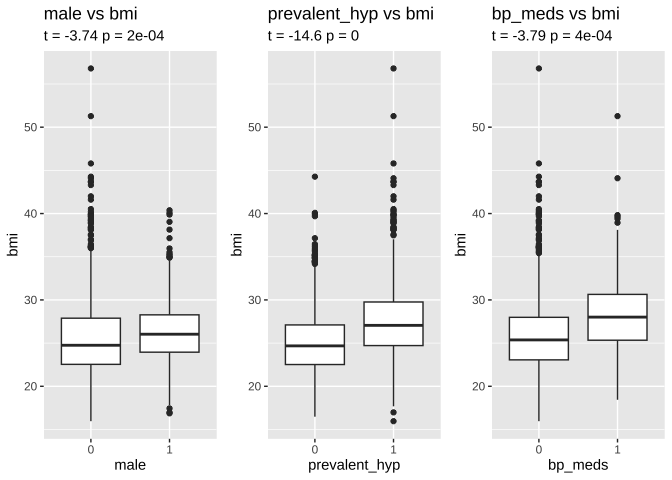

```r
p1 <- boxplot_tt("bmi", "male")
p2 <- boxplot_tt("bmi", "prevalent_hyp")
p3 <- boxplot_tt("bmi", "bp_meds")

grid.arrange(p1, p2, p3, nrow = 1)
```

## hypertension (sys_bp)

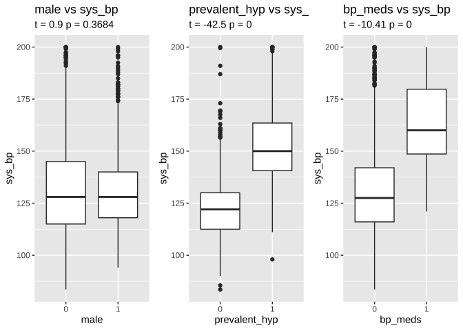

```r
p1 <- boxplot_tt("sys_bp", "male")
p2 <- boxplot_tt("sys_bp", "prevalent_hyp")
p3 <- boxplot_tt("sys_bp", "bp_meds")

grid.arrange(p1, p2, p3, nrow = 1)
```

## glucose level

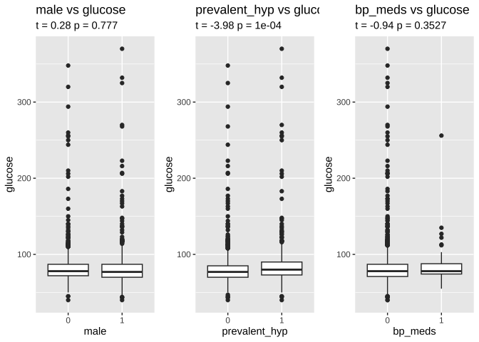

```r
p1 <- boxplot_tt("glucose", "male")
p2 <- boxplot_tt("glucose", "prevalent_hyp")
p3 <- boxplot_tt("glucose", "bp_meds")

grid.arrange(p1, p2, p3, nrow = 1)
```

## cholesterol level

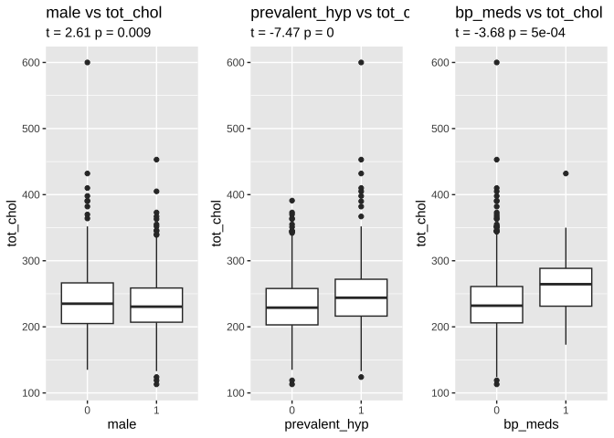

```r
p1 <- boxplot_tt("tot_chol", "male")
p2 <- boxplot_tt("tot_chol", "prevalent_hyp")
p3 <- boxplot_tt("tot_chol", "bp_meds")

grid.arrange(p1, p2, p3, nrow = 1)
```

# NA Assessment

As a last step before fitting the models, we need to take care of NAs in these 6 variables. As mentioned in the beginning, we do this here in order not to bias the EDA.

In case of imputation, we will apply the same procedure blindly to the test set.

`bmi` is significantly different for males and females. There are only 12 values missing. We will impute the NAs with the median of each gender in either risk or no-risk group.

`bp_meds` is a very important variable, and not easy to impute, so we don’t want to run risks here. We see from the table below that the people where blood pressure (bp) medication was not recorded have (median) bp values compatible with people who have either high or low blood pressure AND do not take medications. This could justify the imputation. At the same time, this is a very important variable, associated with drug use. We don’t want to run this risk. We will therefore discard people where it is not known whether they take medications.

## bmi

```r
# bmi ~ male
ggbetweenstats(
   data = train,
   x = male,
   y = bmi
)
```

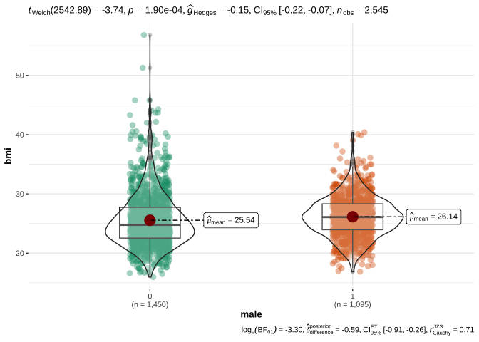

## glucose

```r
# glucose ~ hypertension
ggbetweenstats(
   data = train,
   x = prevalent_hyp,
   y = glucose
)
```

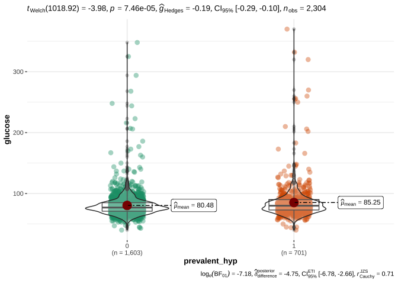

## cholesterol

```r
# cholesterol ~ hypertension
ggbetweenstats(
   data = train,
   x = prevalent_hyp,
   y = tot_chol
)
```

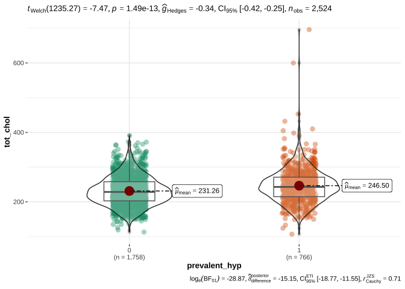

## bp_meds

```r
# bp_meds ~ prevalent_hyp
df %>%
  select(sys_bp, prevalent_hyp, bp_meds) %>%
  group_by(bp_meds, prevalent_hyp) %>%
  summarise(
    median_sys_bp = median(sys_bp),
    count_prevalent_hyp = n()
  )
```

```
## # A tibble: 5 × 4
## # Groups:   bp_meds [3]
##   bp_meds prevalent_hyp median_sys_bp count_prevalent_hyp
##   <fct>   <fct>                 <dbl>               <int>
## 1 0       0                      122                 2891
## 2 0       1                      150.                1170
## 3 1       1                      165                  124
## 4 <NA>    0                      121                   31
## 5 <NA>    1                      154.                  22
```

NA imputation on train *and* test set

```r
# ------------------------- train --------------------------------------------
train <- train %>%
   # impute the bmi as the median of males/females
   group_by(ten_year_chd, male) %>%
   mutate(bmi = ifelse(is.na(bmi), median(bmi, na.rm = T),bmi)) %>%
   ungroup() %>%

   # impute glucose and cholesterol level as the median of prevalent_hyp
   group_by(ten_year_chd, prevalent_hyp) %>%
   mutate(glucose = ifelse(is.na(glucose), median(glucose, na.rm=T), glucose)) %>%
   mutate(tot_chol = ifelse(is.na(tot_chol), median(tot_chol, na.rm=T), tot_chol)) %>%
   ungroup() %>%

   # remove people where bp_meds is not unknown
   filter(!is.na(bp_meds)) %>%

   # remove people with no information about education level
   filter(!is.na(education)) %>%

   # # remove the mean from numerical variables
   # mutate_if(is.numeric, ~ . - mean(., na.rm = TRUE)) %>%

   # remove residual NAs
   na.omit()




train %>%
   select(
      ten_year_chd, age, sys_bp, bmi, glucose, tot_chol,
      male, prevalent_hyp, bp_meds, education
   ) %>%
   diagnose %>%
   flextable
```

| variables | types | missing_count | missing_percent | unique_count | unique_rate |
| --- | --- | --- | --- | --- | --- |
| ten_year_chd | factor | 0 | 0 | 2 | 0.0008173273 |
| age | numeric | 0 | 0 | 39 | 0.0159378831 |
| sys_bp | numeric | 0 | 0 | 198 | 0.0809154066 |
| bmi | numeric | 0 | 0 | 1,094 | 0.4470780548 |
| glucose | numeric | 0 | 0 | 119 | 0.0486309767 |
| tot_chol | numeric | 0 | 0 | 225 | 0.0919493257 |
| male | factor | 0 | 0 | 2 | 0.0008173273 |
| prevalent_hyp | factor | 0 | 0 | 2 | 0.0008173273 |
| bp_meds | factor | 0 | 0 | 2 | 0.0008173273 |
| education | factor | 0 | 0 | 4 | 0.0016346547 |

```r
# ------------------------- test --------------------------------------------
test <- test %>%
   # impute the bmi as the median of males/females
   group_by(ten_year_chd, male) %>%
   mutate(bmi = ifelse(is.na(bmi), median(bmi, na.rm = T),bmi)) %>%
   ungroup() %>%

   # impute glucose and cholesterol level as the median of prevalent_hyp
   group_by(ten_year_chd, prevalent_hyp) %>%
   mutate(glucose = ifelse(is.na(glucose), median(glucose, na.rm=T), glucose)) %>%
   mutate(tot_chol = ifelse(is.na(tot_chol), median(tot_chol, na.rm=T), tot_chol)) %>%
   ungroup() %>%

   # remove people where bp_meds is not unknown
   filter(!is.na(bp_meds)) %>%

   # remove people with no information about education level
   filter(!is.na(education)) %>%

   # # remove the mean from numerical variables
   # mutate_if(is.numeric, ~ . - mean(., na.rm = TRUE)) %>%

   # remove residual NAs
   na.omit()




test %>%
   select(
      ten_year_chd, age, sys_bp, bmi, glucose, tot_chol,
      male, prevalent_hyp, bp_meds, education
   ) %>%
   diagnose %>%
   flextable
```

| variables | types | missing_count | missing_percent | unique_count | unique_rate |
| --- | --- | --- | --- | --- | --- |
| ten_year_chd | factor | 0 | 0 | 2 | 0.00127551 |
| age | numeric | 0 | 0 | 37 | 0.02359694 |
| sys_bp | numeric | 0 | 0 | 191 | 0.12181122 |
| bmi | numeric | 0 | 0 | 855 | 0.54528061 |
| glucose | numeric | 0 | 0 | 101 | 0.06441327 |
| tot_chol | numeric | 0 | 0 | 211 | 0.13456633 |
| male | factor | 0 | 0 | 2 | 0.00127551 |
| prevalent_hyp | factor | 0 | 0 | 2 | 0.00127551 |
| bp_meds | factor | 0 | 0 | 2 | 0.00127551 |
| education | factor | 0 | 0 | 4 | 0.00255102 |

# Analytic strategy

**It appears that there are two interesting questions:**

1. How well is the risk predicted by generic factors alone? (such as age, bmi and blood pressure)
2. How much can we increase the prediction if we include other variables? Does the prediction decreases because of the correlation between numeric and categorical variables?

Since we allowed some correlated variables to enter the model, we will pay close attention to the VIF (variance inflation factor).

After the “best” model is detemined by manual stepwise regression, we will compare the former to an automatic stepwise regression carried out using the AIC criterion alone.

# Logistic regression

Create a function to carry out the logistic regression and print out the summary and the ROC curve and returns the estimated probabilities (`phat`) to use later to build the confusion matrix.

```r
do_logistic_regression <- function(EVs, train_data = train, test_data = test, thresh = 0.5) {

   # Assemble the formula
   formula_string <- paste(EVs, collapse = " + ")
   formula_obj <- as.formula(paste("ten_year_chd ~", formula_string))

   fit <- glm(formula_obj, family = "binomial", data = train_data)

   # Print a summary
   # summary(fit) %>% print()
   if (length(EVs) > 1) {
      jtools::summ(fit, confint = T, vifs = T, scale = T, digits = 2) %>% print()
   } else {
      jtools::summ(fit, confint = T, vifs = F, scale = T, digits = 2) %>% print()
   }


   # # Standard R summary
   # summary(fit) %>% print()


   # Estimated probability values from the logistic model
   phat = predict(fit, newdata = test_data, type = "response")


   # ROC curve using pROC::roc
   # https://www.youtube.com/watch?v=qcvAqAH60Yw&t=493s
   par(pty = "s")
   pROC::roc(
      test_data$ten_year_chd ~ phat, plot = TRUE, print.auc = TRUE, legacy.axes = TRUE,
      xlab="% False Positives", ylab = "% True Positives", col = "#377eb8", lwd = 4
   )



   # Confusion matrix and derived quantities - using caret::confusionmatrix
   sprintf("\n Using a threshold for prediction = %.2f \n\n", thresh) %>% cat()

   thresh <- thresh
   predicted <- ifelse(phat > thresh, 1, 0)

   actual_predicted <- tibble(
      actual = test_data$ten_year_chd,
      predicted = ifelse(phat > thresh, 1, 0)
   )

   caret::confusionMatrix(
      as.factor(predicted), # predicted
      as.factor(test_data$ten_year_chd), # actual
      positive = "1"  # the positive class in our case is "1"
   ) %>% print()

   return(phat)
}
```

## Manual stepwise

**NB:** In the following tables the coefficients are reported as standardized, to allow: (1) interpreting the intercept in terms of probability, and (2) to compare the magnitude of the coefficients.

If one desires to inspect the non-scaled coefficients, it is sufficient to uncomment the line in the `do_logistic_regression` function above which reports the R base summary of fitting the model to the data

### Maximal model

Maximal model, including *all* the variables in the dataset. We use this only as a benchmark for the models instructed by EDA.

We observe high VIF values in `sys_bp` and `dia_bp` - as expected.

```r
EVs <- train %>% select(-ten_year_chd) %>% colnames()
phat <- do_logistic_regression(EVs, thresh = 0.5)
```

```
## MODEL INFO:
## Observations: 2447
## Dependent Variable: ten_year_chd
## Type: Generalized linear model
##   Family: binomial
##   Link function: logit
##
## MODEL FIT:
## χ²(17) = 238.36, p = 0.00
## Pseudo-R² (Cragg-Uhler) = 0.16
## Pseudo-R² (McFadden) = 0.12
## AIC = 1859.26, BIC = 1963.70
##
## Standard errors: MLE
## ----------------------------------------------------------------------
##                            Est.    2.5%   97.5%   z val.      p    VIF
## ----------------------- ------- ------- ------- -------- ------ ------
## (Intercept)               -2.22   -2.55   -1.90   -13.55   0.00
## male1                      0.37    0.10    0.63     2.72   0.01   1.25
## age                        0.52    0.39    0.66     7.38   0.00   1.32
## education2                -0.32   -0.62   -0.02    -2.09   0.04   1.13
## education3                -0.36   -0.73    0.01    -1.89   0.06   1.13
## education4                -0.03   -0.42    0.36    -0.15   0.88   1.13
## current_smoker1            0.17   -0.21    0.55     0.88   0.38   2.59
## cigs_per_day               0.17   -0.01    0.35     1.84   0.07   2.73
## bp_meds1                   0.24   -0.37    0.85     0.77   0.44   1.11
## prevalent_stroke1          0.86   -0.35    2.07     1.40   0.16   1.04
## prevalent_hyp1             0.39    0.05    0.72     2.27   0.02   1.99
## diabetes1                  0.42   -0.36    1.20     1.06   0.29   1.89
## tot_chol                   0.01   -0.11    0.13     0.18   0.86   1.07
## sys_bp                     0.25    0.04    0.45     2.40   0.02   3.42
## dia_bp                    -0.02   -0.20    0.17    -0.18   0.86   2.71
## bmi                        0.08   -0.04    0.21     1.28   0.20   1.26
## heart_rate                -0.08   -0.20    0.05    -1.21   0.23   1.10
## glucose                    0.12   -0.01    0.24     1.78   0.08   1.90
## ----------------------------------------------------------------------
##
## Continuous predictors are mean-centered and scaled by 1 s.d. The outcome variable remains in its original units.
```

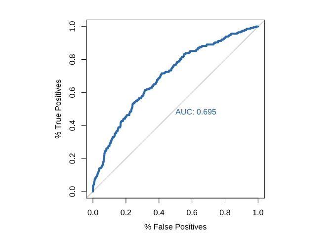

```
##
##  Using a threshold for prediction = 0.50
##
## Confusion Matrix and Statistics
##
##           Reference
## Prediction    0    1
##          0 1325  214
##          1   14   15
##
##                Accuracy : 0.8546
##                  95% CI : (0.8362, 0.8717)
##     No Information Rate : 0.854
##     P-Value [Acc > NIR] : 0.4891
##
##                   Kappa : 0.0863
##
##  Mcnemar's Test P-Value : <2e-16
##
##             Sensitivity : 0.065502
##             Specificity : 0.989544
##          Pos Pred Value : 0.517241
##          Neg Pred Value : 0.860949
##              Prevalence : 0.146046
##          Detection Rate : 0.009566
##    Detection Prevalence : 0.018495
##       Balanced Accuracy : 0.527523
##
##        'Positive' Class : 1
##
```

### Full with selected variables

This is the “full” model with all the variables chosen based on the EDA.

No problems with collinearity.

```r
EVs  <- c(
   "male", "prevalent_hyp", "bp_meds", "education",
   "age", "sys_bp", "bmi", "glucose", "tot_chol"
)

phat <- do_logistic_regression(EVs, thresh = 0.5)
```

```
## MODEL INFO:
## Observations: 2447
## Dependent Variable: ten_year_chd
## Type: Generalized linear model
##   Family: binomial
##   Link function: logit
##
## MODEL FIT:
## χ²(11) = 220.57, p = 0.00
## Pseudo-R² (Cragg-Uhler) = 0.15
## Pseudo-R² (McFadden) = 0.11
## AIC = 1865.04, BIC = 1934.67
##
## Standard errors: MLE
## -------------------------------------------------------------------
##                         Est.    2.5%   97.5%   z val.      p    VIF
## -------------------- ------- ------- ------- -------- ------ ------
## (Intercept)            -2.18   -2.43   -1.93   -16.95   0.00
## male1                   0.54    0.29    0.78     4.34   0.00   1.07
## prevalent_hyp1          0.36    0.03    0.68     2.16   0.03   1.91
## bp_meds1                0.31   -0.29    0.90     1.01   0.31   1.08
## education2             -0.31   -0.61   -0.01    -2.03   0.04   1.11
## education3             -0.36   -0.73    0.01    -1.91   0.06   1.11
## education4             -0.02   -0.41    0.36    -0.12   0.90   1.11
## age                     0.49    0.36    0.62     7.28   0.00   1.20
## sys_bp                  0.23    0.07    0.39     2.88   0.00   2.11
## bmi                     0.06   -0.06    0.18     0.98   0.33   1.16
## glucose                 0.15    0.06    0.25     3.17   0.00   1.02
## tot_chol                0.01   -0.11    0.13     0.17   0.86   1.06
## -------------------------------------------------------------------
##
## Continuous predictors are mean-centered and scaled by 1 s.d. The outcome variable remains in its original units.
```

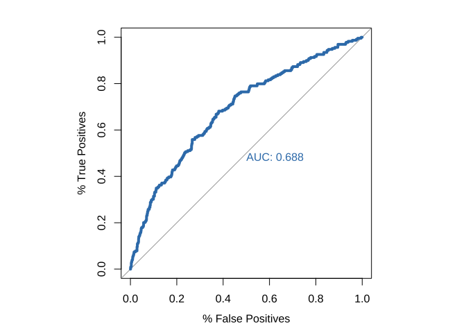

```
##
##  Using a threshold for prediction = 0.50
##
## Confusion Matrix and Statistics
##
##           Reference
## Prediction    0    1
##          0 1328  220
##          1   11    9
##
##                Accuracy : 0.8527
##                  95% CI : (0.8342, 0.8699)
##     No Information Rate : 0.854
##     P-Value [Acc > NIR] : 0.5741
##
##                   Kappa : 0.05
##
##  Mcnemar's Test P-Value : <2e-16
##
##             Sensitivity : 0.03930
##             Specificity : 0.99178
##          Pos Pred Value : 0.45000
##          Neg Pred Value : 0.85788
##              Prevalence : 0.14605
##          Detection Rate : 0.00574
##    Detection Prevalence : 0.01276
##       Balanced Accuracy : 0.51554
##
##        'Positive' Class : 1
##
```

### Remove no-effect EVs

Remove education, bp_meds, bmi, tot_chol since they have no effect on the model.

The AIC slightly decreases with respect to the full model.

```r
# Remove education, bp_meds, bmi, tot_chol since they have
# no effect on the model
EVs  <- c(
   "male", "prevalent_hyp",
   "age", "sys_bp", "glucose"
)

phat <- do_logistic_regression(EVs, thresh = 0.5)
```

```
## MODEL INFO:
## Observations: 2447
## Dependent Variable: ten_year_chd
## Type: Generalized linear model
##   Family: binomial
##   Link function: logit
##
## MODEL FIT:
## χ²(5) = 211.34, p = 0.00
## Pseudo-R² (Cragg-Uhler) = 0.15
## Pseudo-R² (McFadden) = 0.10
## AIC = 1862.28, BIC = 1897.09
##
## Standard errors: MLE
## -------------------------------------------------------------------
##                         Est.    2.5%   97.5%   z val.      p    VIF
## -------------------- ------- ------- ------- -------- ------ ------
## (Intercept)            -2.34   -2.55   -2.13   -21.75   0.00
## male1                   0.57    0.33    0.81     4.69   0.00   1.03
## prevalent_hyp1          0.38    0.05    0.70     2.30   0.02   1.88
## age                     0.52    0.39    0.65     8.03   0.00   1.12
## sys_bp                  0.27    0.12    0.42     3.44   0.00   1.99
## glucose                 0.15    0.06    0.25     3.18   0.00   1.01
## -------------------------------------------------------------------
##
## Continuous predictors are mean-centered and scaled by 1 s.d. The outcome variable remains in its original units.
```

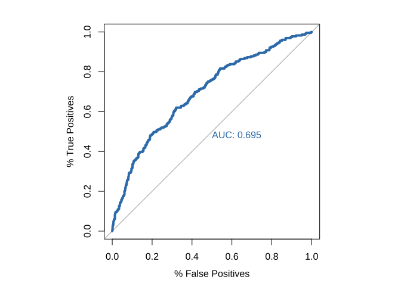

```
##
##  Using a threshold for prediction = 0.50
##
## Confusion Matrix and Statistics
##
##           Reference
## Prediction    0    1
##          0 1332  221
##          1    7    8
##
##                Accuracy : 0.8546
##                  95% CI : (0.8362, 0.8717)
##     No Information Rate : 0.854
##     P-Value [Acc > NIR] : 0.4891
##
##                   Kappa : 0.0485
##
##  Mcnemar's Test P-Value : <2e-16
##
##             Sensitivity : 0.034934
##             Specificity : 0.994772
##          Pos Pred Value : 0.533333
##          Neg Pred Value : 0.857695
##              Prevalence : 0.146046
##          Detection Rate : 0.005102
##    Detection Prevalence : 0.009566
##       Balanced Accuracy : 0.514853
##
##        'Positive' Class : 1
##
```

### Remove prevalent_hyp

Remove prevalent_hyp since it is only marginally significant

Note that the AIC only marginally increases (less than 0.2%) and this model is much simpler and requires only 4 variables, two of which are common demographic variables (`age` and sex), while the other two can be easily gathered through a pressure measurement and a blood test.

```r
# Remove prevalent_hyp since it is only marginally significant
EVs  <- c(
   "male", "age", "sys_bp", "glucose"
)

phat <- do_logistic_regression(EVs, thresh = 0.5)
```

```
## MODEL INFO:
## Observations: 2447
## Dependent Variable: ten_year_chd
## Type: Generalized linear model
##   Family: binomial
##   Link function: logit
##
## MODEL FIT:
## χ²(4) = 206.10, p = 0.00
## Pseudo-R² (Cragg-Uhler) = 0.14
## Pseudo-R² (McFadden) = 0.10
## AIC = 1865.51, BIC = 1894.52
##
## Standard errors: MLE
## ----------------------------------------------------------------
##                      Est.    2.5%   97.5%   z val.      p    VIF
## ----------------- ------- ------- ------- -------- ------ ------
## (Intercept)         -2.22   -2.40   -2.04   -23.85   0.00
## male1                0.58    0.34    0.82     4.80   0.00   1.03
## age                  0.53    0.40    0.65     8.17   0.00   1.11
## sys_bp               0.39    0.27    0.50     6.57   0.00   1.13
## glucose              0.15    0.06    0.24     3.16   0.00   1.01
## ----------------------------------------------------------------
##
## Continuous predictors are mean-centered and scaled by 1 s.d. The outcome variable remains in its original units.
```

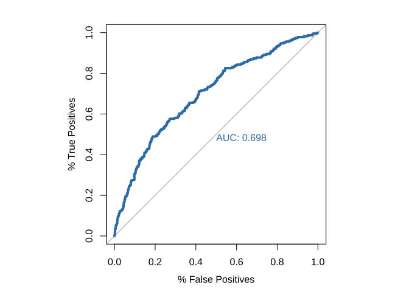

```
##
##  Using a threshold for prediction = 0.50
##
## Confusion Matrix and Statistics
##
##           Reference
## Prediction    0    1
##          0 1331  221
##          1    8    8
##
##                Accuracy : 0.854
##                  95% CI : (0.8355, 0.8711)
##     No Information Rate : 0.854
##     P-Value [Acc > NIR] : 0.5176
##
##                   Kappa : 0.0471
##
##  Mcnemar's Test P-Value : <2e-16
##
##             Sensitivity : 0.034934
##             Specificity : 0.994025
##          Pos Pred Value : 0.500000
##          Neg Pred Value : 0.857603
##              Prevalence : 0.146046
##          Detection Rate : 0.005102
##    Detection Prevalence : 0.010204
##       Balanced Accuracy : 0.514480
##
##        'Positive' Class : 1
##
```

### Include cigs_per_day

Despite not having found a substantial effect of smoking on the 10-year risk of CHD, the automatic stepwise regression (below) identified `cigs_per_day` as an important predictive factor.

It is unclear to me why this is the case. However, the effect on the predictability appears relevant, therefore the last model includes also the # of cigarettes smoked per day. This is also in consideration of the fact that heavy smokers usually tend to underestimate the amount of cigarettes smoked.

The AIC decreases with respect to the previous model, and there is no evidence of dangerous collinearity.

```r
# The stepwise regression - below - identified cigs_per_day as an important factor.
# I will therefore add it to the model.
EVs  <- c(
   "male", "age", "sys_bp", "glucose", "cigs_per_day"
)

phat <- do_logistic_regression(EVs, thresh = 0.5)
```

```
## MODEL INFO:
## Observations: 2447
## Dependent Variable: ten_year_chd
## Type: Generalized linear model
##   Family: binomial
##   Link function: logit
##
## MODEL FIT:
## χ²(5) = 216.92, p = 0.00
## Pseudo-R² (Cragg-Uhler) = 0.15
## Pseudo-R² (McFadden) = 0.11
## AIC = 1856.70, BIC = 1891.51
##
## Standard errors: MLE
## -----------------------------------------------------------------
##                       Est.    2.5%   97.5%   z val.      p    VIF
## ------------------ ------- ------- ------- -------- ------ ------
## (Intercept)          -2.18   -2.36   -1.99   -23.18   0.00
## male1                 0.44    0.19    0.70     3.45   0.00   1.16
## age                   0.57    0.44    0.69     8.54   0.00   1.16
## sys_bp                0.39    0.28    0.51     6.64   0.00   1.13
## glucose               0.15    0.06    0.25     3.23   0.00   1.01
## cigs_per_day          0.20    0.08    0.32     3.32   0.00   1.20
## -----------------------------------------------------------------
##
## Continuous predictors are mean-centered and scaled by 1 s.d. The outcome variable remains in its original units.
```

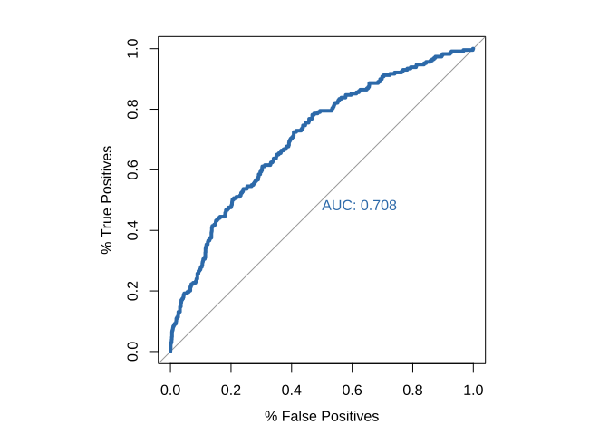

```
##
##  Using a threshold for prediction = 0.50
##
## Confusion Matrix and Statistics
##
##           Reference
## Prediction    0    1
##          0 1332  218
##          1    7   11
##
##                Accuracy : 0.8565
##                  95% CI : (0.8382, 0.8735)
##     No Information Rate : 0.854
##     P-Value [Acc > NIR] : 0.4043
##
##                   Kappa : 0.0693
##
##  Mcnemar's Test P-Value : <2e-16
##
##             Sensitivity : 0.048035
##             Specificity : 0.994772
##          Pos Pred Value : 0.611111
##          Neg Pred Value : 0.859355
##              Prevalence : 0.146046
##          Detection Rate : 0.007015
##    Detection Prevalence : 0.011480
##       Balanced Accuracy : 0.521404
##
##        'Positive' Class : 1
##
```

### Final model using thr = 0.1

Leaving the default threshold of 0.5 for prediction leads to identifying too few true positives. For this reason, we decided to maximise the Sensitivity (TP / (TP+FN)) even at the expense of assigning high risk of CHD to some people who are not.

This rationale is motivated by the fact that in this case the decision is not about doing or not doing an open-heart surgery, but rather to start to monitor people who might be at high risk. For this reason, it is of paramount important to include all the people who might be at risk even if they will turn out not to be so.

For all these reasons, the threshold for risk detection is lowered to 0.1.

```r
# The main aim is to use the model to identify the highest amount of true positives
# and minimize false negatives

EVs  <- c(
   "male", "age", "sys_bp", "glucose", "cigs_per_day"
)

phat <- do_logistic_regression(EVs, thresh = 0.1)
```

```
## MODEL INFO:
## Observations: 2447
## Dependent Variable: ten_year_chd
## Type: Generalized linear model
##   Family: binomial
##   Link function: logit
##
## MODEL FIT:
## χ²(5) = 216.92, p = 0.00
## Pseudo-R² (Cragg-Uhler) = 0.15
## Pseudo-R² (McFadden) = 0.11
## AIC = 1856.70, BIC = 1891.51
##
## Standard errors: MLE
## -----------------------------------------------------------------
##                       Est.    2.5%   97.5%   z val.      p    VIF
## ------------------ ------- ------- ------- -------- ------ ------
## (Intercept)          -2.18   -2.36   -1.99   -23.18   0.00
## male1                 0.44    0.19    0.70     3.45   0.00   1.16
## age                   0.57    0.44    0.69     8.54   0.00   1.16
## sys_bp                0.39    0.28    0.51     6.64   0.00   1.13
## glucose               0.15    0.06    0.25     3.23   0.00   1.01
## cigs_per_day          0.20    0.08    0.32     3.32   0.00   1.20
## -----------------------------------------------------------------
##
## Continuous predictors are mean-centered and scaled by 1 s.d. The outcome variable remains in its original units.
```

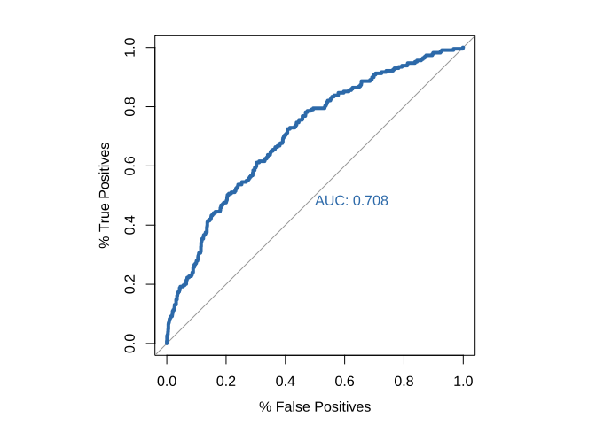

```
##
##  Using a threshold for prediction = 0.10
##
## Confusion Matrix and Statistics
##
##           Reference
## Prediction   0   1
##          0 585  38
##          1 754 191
##
##                Accuracy : 0.4949
##                  95% CI : (0.4699, 0.52)
##     No Information Rate : 0.854
##     P-Value [Acc > NIR] : 1
##
##                   Kappa : 0.118
##
##  Mcnemar's Test P-Value : <2e-16
##
##             Sensitivity : 0.8341
##             Specificity : 0.4369
##          Pos Pred Value : 0.2021
##          Neg Pred Value : 0.9390
##              Prevalence : 0.1460
##          Detection Rate : 0.1218
##    Detection Prevalence : 0.6027
##       Balanced Accuracy : 0.6355
##
##        'Positive' Class : 1
##
```

Confusion matrix and its derived metrics (manually calculated). Values are not shown. Only to double-check the values from the `confusionmatrix` function.

```r
# # Binary prediction from the estimated probability values
# thresh <- 0.1
# predicted <- ifelse(phat > thresh, 1, 0)
#
# actual_predicted <- tibble(
#    actual = test$ten_year_chd,
#    predicted = ifelse(phat > thresh, 1, 0)
# )
#
# cm <- actual_predicted %>%
#   summarise(
#     TP = sum(actual == 1 & predicted == 1),
#     TN = sum(actual == 0 & predicted == 0),
#     FP = sum(actual == 0 & predicted == 1),
#     FN = sum(actual == 1 & predicted == 0)
#   )
#
# cm %>% print
#
# TP <- cm$TP
# TN <- cm$TN
# FP <- cm$FP
# FN <- cm$FN
#
#
# accuracy <- (TP + TN) / (TP+TN+FP+FN)
# print(paste0("Accuracy = ", round(accuracy,4)))
#
# sensitivity <- TP / (TP + FN)
# print(paste0("Sensitivity / Recall / TPR = ", round(sensitivity,4)))
#
# specificity <- TN / (TN + FP)
# print(paste0("Specificity / TNR = ", round(specificity,4)))
#
# PPV <- TP / (TP+FP)
# print(paste0("Positive Predictive Value = ", round(PPV,2)))
#
# NPV <- TN / (TN+FN)
# print(paste0("Negative Predictive Value = ", round(NPV,2)))
```

## Automatic stepwise

*This* particular stepwise regression leads to a much more complex model. It is important to note that the particular order of the predictors can change the final estimated “best” model (based on AIC).

However what is very important is that the `cigs_per_day` is identified as an important predictor, despite our EDA repeatedly disconfirmed so. The reasons are therefore to be explored, however for the time being we will try to include it into our manually built model (see above.)

```r
library(MASS)

fullModel = glm(
   ten_year_chd ~ male + prevalent_hyp + bp_meds + age + sys_bp + glucose + tot_chol,
   family = "binomial", data = train
)

fullModel = glm(ten_year_chd ~ ., family = "binomial", data = train)

nullModel = glm(ten_year_chd ~ 1, family = "binomial", data = train)

step_fit <- stepAIC(
   fullModel, direction = 'backward',
   scope = list(upper = fullModel, lower = nullModel), trace = 0
)

# step_fit %>% summary()
step_fit %>% jtools::summ(confint = T, vifs = T, digits = 2) %>% print()
```

```
## MODEL INFO:
## Observations: 2447
## Dependent Variable: ten_year_chd
## Type: Generalized linear model
##   Family: binomial
##   Link function: logit
##
## MODEL FIT:
## χ²(10) = 232.82, p = 0.00
## Pseudo-R² (Cragg-Uhler) = 0.16
## Pseudo-R² (McFadden) = 0.11
## AIC = 1850.79, BIC = 1914.62
##
## Standard errors: MLE
## ----------------------------------------------------------------------
##                            Est.    2.5%   97.5%   z val.      p    VIF
## ----------------------- ------- ------- ------- -------- ------ ------
## (Intercept)               -7.56   -8.79   -6.33   -12.07   0.00
## male1                      0.38    0.12    0.63     2.86   0.00   1.19
## age                        0.06    0.05    0.08     7.68   0.00   1.22
## education2                -0.34   -0.64   -0.04    -2.24   0.03   1.10
## education3                -0.39   -0.76   -0.02    -2.05   0.04   1.10
## education4                -0.03   -0.41    0.36    -0.13   0.90   1.10
## cigs_per_day               0.02    0.01    0.03     3.54   0.00   1.22
## prevalent_stroke1          0.97   -0.21    2.15     1.61   0.11   1.01
## prevalent_hyp1             0.38    0.05    0.70     2.29   0.02   1.90
## sys_bp                     0.01    0.01    0.02     3.31   0.00   2.02
## glucose                    0.01    0.00    0.01     3.34   0.00   1.01
## ----------------------------------------------------------------------
```

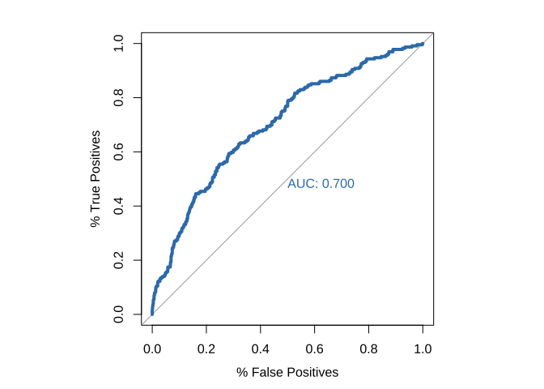

```
##
## Call:
## roc.formula(formula = test$ten_year_chd ~ phat_step_fit, plot = TRUE,     print.auc = TRUE, legacy.axes = TRUE, xlab = "% False Positives",     ylab = "% True Positives", col = "#377eb8", lwd = 4)
##
## Data: phat_step_fit in 1339 controls (test$ten_year_chd 0) < 229 cases (test$ten_year_chd 1).
## Area under the curve: 0.7004
```

```r
# Estimated probability values from the logistic model
phat_step_fit = predict(step_fit, newdata = test, type = "response")

# ROC curve
# pROC::roc(test$ten_year_chd ~ phat_step_fit, plot = TRUE, print.auc = TRUE)

par(pty = "s")
pROC::roc(
   test$ten_year_chd ~ phat_step_fit, plot = TRUE, print.auc = TRUE, legacy.axes = TRUE,
   xlab="% False Positives", ylab = "% True Positives", col = "#377eb8", lwd = 4
)
```

Evaluate predictivity of the stepwise model

```r
# Binary prediction from the estimated probability values
thresh <- 0.1
predicted <- ifelse(phat_step_fit > thresh, 1, 0)

actual_predicted <- tibble(
   actual = test$ten_year_chd,
   predicted = ifelse(phat_step_fit > thresh, 1, 0)
)

caret::confusionMatrix(
   as.factor(predicted), # predicted
   as.factor(test$ten_year_chd), # actual
   positive = "1"  # the positive class in our case is "1"
)
```

```
## Confusion Matrix and Statistics
##
##           Reference
## Prediction   0   1
##          0 610  40
##          1 729 189
##
##                Accuracy : 0.5096
##                  95% CI : (0.4845, 0.5346)
##     No Information Rate : 0.854
##     P-Value [Acc > NIR] : 1
##
##                   Kappa : 0.125
##
##  Mcnemar's Test P-Value : <2e-16
##
##             Sensitivity : 0.8253
##             Specificity : 0.4556
##          Pos Pred Value : 0.2059
##          Neg Pred Value : 0.9385
##              Prevalence : 0.1460
##          Detection Rate : 0.1205
##    Detection Prevalence : 0.5855
##       Balanced Accuracy : 0.6404
##
##        'Positive' Class : 1
##
```

## Balanced samples

Our sample is very unbalanced. We will select an equal number of people with and without risk in both train and test set to assess whether this will help model performance.

```r
set.seed(9999)

min_train <- min(
   nrow(train[train$ten_year_chd == 1,]),
   nrow(train[train$ten_year_chd == 0,])
)

balanced_train <- train %>%
   group_by(ten_year_chd) %>%
   slice_sample(n = min_train)


min_test <- min(
   nrow(test[test$ten_year_chd == 1,]),
   nrow(test[test$ten_year_chd == 0,])
)

balanced_test <- test %>%
   group_by(ten_year_chd) %>%
   slice_sample(n = min_test)


# Full model with the selected variables
EVs  <- c(
   "male", "prevalent_hyp", "bp_meds", "education",
   "age", "sys_bp", "bmi", "glucose", "tot_chol"
)


# Remove education, bp_meds, bmi, tot_chol since they have
# no effect on the model
EVs  <- c(
   "male", "prevalent_hyp",
   "age", "sys_bp", "glucose"
)


# Remove prevalent_hyp since it is only marginally significant
EVs  <- c(
   "male", "age", "sys_bp", "glucose"
)


# The stepwise regression - below - identified cigs_per_day as an important factor.
# I will therefore add it to the model.
EVs  <- c(
   "male", "age", "sys_bp", "glucose", "cigs_per_day"
)


phat <- do_logistic_regression(
   EVs,
   train_data = balanced_train, test_data = balanced_test,
   thresh = 0.2
)
```

```
## MODEL INFO:
## Observations: 730
## Dependent Variable: ten_year_chd
## Type: Generalized linear model
##   Family: binomial
##   Link function: logit
##
## MODEL FIT:
## χ²(5) = 135.30, p = 0.00
## Pseudo-R² (Cragg-Uhler) = 0.23
## Pseudo-R² (McFadden) = 0.13
## AIC = 888.69, BIC = 916.25
##
## Standard errors: MLE
## -----------------------------------------------------------------
##                       Est.    2.5%   97.5%   z val.      p    VIF
## ------------------ ------- ------- ------- -------- ------ ------
## (Intercept)          -0.14   -0.37    0.08    -1.25   0.21
## male1                 0.34   -0.00    0.68     1.96   0.05   1.14
## age                   0.59    0.41    0.77     6.52   0.00   1.13
## sys_bp                0.46    0.28    0.64     5.10   0.00   1.06
## glucose               0.28    0.06    0.49     2.51   0.01   1.01
## cigs_per_day          0.33    0.15    0.51     3.59   0.00   1.21
## -----------------------------------------------------------------
##
## Continuous predictors are mean-centered and scaled by 1 s.d. The outcome variable remains in its original units.
```

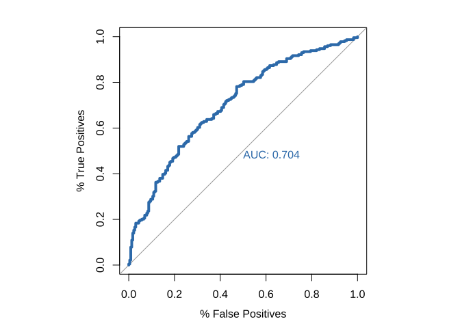

```
##
##  Using a threshold for prediction = 0.20
##
## Confusion Matrix and Statistics
##
##           Reference
## Prediction   0   1
##          0  16   5
##          1 213 224
##
##                Accuracy : 0.524
##                  95% CI : (0.4772, 0.5706)
##     No Information Rate : 0.5
##     P-Value [Acc > NIR] : 0.1632
##
##                   Kappa : 0.048
##
##  Mcnemar's Test P-Value : <2e-16
##
##             Sensitivity : 0.97817
##             Specificity : 0.06987
##          Pos Pred Value : 0.51259
##          Neg Pred Value : 0.76190
##              Prevalence : 0.50000
##          Detection Rate : 0.48908
##    Detection Prevalence : 0.95415
##       Balanced Accuracy : 0.52402
##
##        'Positive' Class : 1
##
```

```r
length(phat)
```

```
## [1] 458
```